# Governance of private Brazilian HEIs

Godoy

2022-08-16

# Introduction

# Variables

## Dimensions to study

This study’s focus is to assess what are, if any, the differences between the governance of for-profit and nonprofit HEIs. To this end, the variables used are separated in four groups, as follows:

### Institutional factors

#### Legal Form

In Brazil, HEIs do not have a legal personality, meaning that they’re unable to sign contracts or own property. The legal matters are attended by what are called Maintainers, which are legal persons that instituted the HEI and are responsible for funding that HEI’s activities (CNE, 2002).

**For-profit**

- **Limited Liability Society**: legal entity composed of two or more people
- **Anonymous society**: same as above, but its ownership is trade as stocks
- **Simple society**: same as the first, but limited to owners from the same professional category

**Nonprofits**

- **Association**: legal entity composed of two or more people, which doesn’t pay dividends to its owners
- **Foundation**: legal entity with no owners, just assets and a statute overseen by the government
- **Parastatal**: An association created by the State for a professional category, to which contribution is mandatory, but its run independently from the government

#### Academic Structure

According to decree 9.235/17, HEIs may be structured in three distinct forms: Faculties, University Centers and Universities. Every private HEI is, *a priori*, a **Faculty.**. This means that the HEI can only operate in one city (CNE,). To become a **University Center**, the HEI must have:

- one fifth of its faculty as full-time employees;
- one third of its faculty with degree of masters or above;
- at least 8 programs approved by the Ministry;
- extension activities for every programs;
- scientific initiation program;
- institutional evaluation of at least 4 out of 5;
- no penalties applied to it in the last two years.

As a **University Center**, the HEI has autonomy to create new programs, although they’ll still need to be certified by the Ministry later. **Universities** have this autonomy as well, and to become one the HEI must have, in addition to the previous requirements: - one third of its faculty as full-time employees; - at least 60% of its programs approved by the Ministry; - four masters and two doctorate programs recognized by the Ministry.

#### Qualification

According to law 9.394/96, Brazilian private HEIs may be qualified as:

**Communitary** HEIs, according to law 12.881/13, are only those certified by the Ministry, and have the possibility of accessing funds open to public HEIs, public infrastructure and firming contracts directly with the State. This certification comes with governance requirements, noted in the next section.

**Confessional** HEIs self-qualified, attending to a confessional and ideological orientation.This qualification doesn’t have governance requirements, but it may indicate patterns in the governance of HEIs.

### Governance

The focus here lies in the governance of the HEI, as structured by its bylaws. Every HEI’s bylaws must be approved by the National Council of Education (CNE, 2002), which may have an isomorphic effect on the overall structure. Beyond this soft regulation, there are some legal requirements for private HEIs, depending on their academic structure and qualification.

According to CNE (2002), all HEIs must:

- have collegiate bodies (art. 206, VI, Brazilian Federal Constitution)
- allow veto power to its maintainer, on financial matters (1.4.1, CNE 282/02)
- faculty must be represented on the collegiate bodies (1.4.1, CNE 282/02)
- identify the method of executive appointment (1.5, CNE 282/02)

**Universities** and **University Centers** must also delegate to their scientific and educational bodies the following decisions: (§ 1º, art. 53, law 9.394/96) - Creation, modification or extinction of programs, - increment or decrease in their offer of program placements, - program content, - planning of research and extension activities, - hiring and dismissing faculty, - faculty career plan.

Finally, **Comunitary** HEIs, according to law 12.881/13, must:

- publish annual reports, including financial,
- disclose any public funds received or used,
- instate a fiscal board, to oversee financial management
- have representatives of academics, students and administrative staff on the academic council

### Stakeholder representation

Based on the works of Viancos González and Ganga Contreras (2021) as well as Choi (2019), nine common stakeholders for HEIs were identified:

- students
- alumni
- academics
- Staff
- Owners
- Government
- Community
- Industry
- Unions

However, there are no rules that mandate or forbid the participation of Rectors and other top executives in the HEI’s boards, thus, I include them as a category, and I further specify each category:

- students: Currently enrolled student;
- alumni: ex-students that completed their programs;
- academics: professors and lecturers;
- executive: members of the top executive team;
- staff: Current employed, non-academics;
- owners: Representatives for the maintainer;
- government: Representatives for any governmental level;
- community: Any person so qualified;
- industry: business person or a representative from a business association;
- unions: Representative for labor unions of academics and/or staff.

Thus, for this work I understand that each of these stakeholders is represented in the governance structure of the HEI if there is a provision of **at least one seat in any of the boards** for them.

That said, there are some minimum requirements for the HEIs in terms of stakeholder representation: **Every HEI** must have at least one academic representative (CNE, 2002). Further, **Communitary** HEIs must have representation of academics, students and administrative staff on their academic board (Law 12.881/13)

### Responsibility distribution

One important dimension of governance is the way the strategic decision process is shared between principal and agent (Fama & Jansen, 1983). According to these authors, this division can be broadly identified in four steps:

- *initiation*: generating proposals,
- *ratification*: choosing what is to be implemented,
- *implementation*: execution of ratified decisions,
- *monitoring*: Performance measure and reward implementation.

Thus, to assess who is responsible for the HEI’s performance, it is important to assess who is represented in each step of the decision making. Thus, based on the bylaws, I try to verify if these steps are assigned to the *Board* (any of them), to the *Executive* team (any member of the top management team).

To make it less abstract, I’ll consider the four dimensions of Universitary autonomy proposed by Esterman and Nokkala (2009): *Academic*, *Financial*, *Organizational* and *Staff*. However, when considering these themes, the implementation step, as proposed by Fama and Jansen (1983) becomes obsolete, since neither top management nor boards effectivelly exectute the policies analysed by the themes proposed by Esterman and Nokkala (2009). Thus, the followinf table lists activities that indicate the responsibility over each theme, for three decision-making steps: *Plan*, *Decide* and *Supervise*:

| **Step** | **Academic** | **Financial** | **Organizational** | **Staff** |
| --- | --- | --- | --- | --- |
| **Plan** | Propose new programs or the termination of existing programs | Propose Budget | Propose changes to the bylaws | Propose hiring, firing and progression |
| **Decide** | Approve new programs or the termination of existing programs | Approve budget | Approve changes to the bylaws | approving hiring, firing and progression |
| **Supervise** | supervise program evaluation | Supervise financials | punish bylaw infringement | supervise and adjudicate on hiring, firing and progression matters |

## Summary of variables

| **Code** | **Variable** | **Values** |
| --- | --- | --- |
| Institutional factors |  |  |
| Maintainer_Type | Legal form of the maintainer | Association, Foundation, Special (Parastatal) , Corporate (Anonymous Society) or Limited (Limited Liability Society & Simple Society) |
| HEI_Type | Academic level of the HEI | University, Uni_Center (Universitary Center) or Faculty |
| Maintainer_Profit | Whether the Maintainer legal form allows profit distribution among owners or executives | For-Profit (Corporate, Limited), Nonprofit (Association, Foundation, Special) |
| Institutional_Category | A variable that combines the previous variables and includes Communitarian and Religious forms | Association, Foundation, Special, Corporate, Limited, University, Uni_Center, Faculty, For-Profit, Nonprofit, Certif_Comunitarian or Certif_Relig |
| **Governance structure** |  |  |
| Board_Amount | Number of upper collegiate bodies stated in the bylaws | Integer |
| Relative_Freq | Proportion of the total HEIs which adopt this amount of boards | Percentage |
| Stakeholder | Which stakeholders are represented in any of the upper boards | Students, alumni, academics, staff, executive, owners, government, community, industry or unions |
| Repres_Freq | Proportion of the total HEIs which have this stakeholder represented at any upper board | Percentage |
| **Governance Process** |  |  |
| Rector Appointment | Type of rector appointment | Universitocracy, academicracy, designatory-colaborative, designatory-directive |
| Governance_Role | What step of decision making is delegated | Plan, decide or supervise |
| Responsible_Party | Governance structure responsible for the decision making step | Board, both, executive or none |
| Bylaw_Freq | Proportion of the total HEIs which have this decision-making responsibility designated in its bylaws | Percentage |

# Descriptive statistics

## Rector Appointment Process

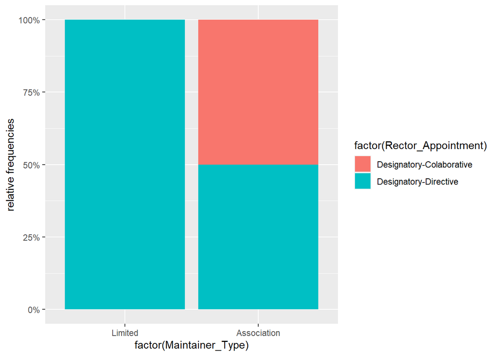

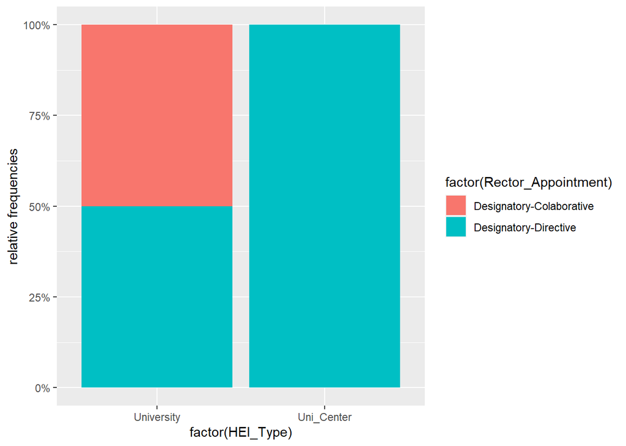

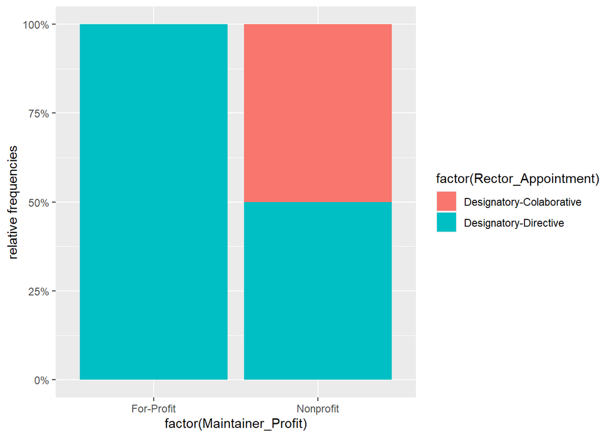

## Number of Boards

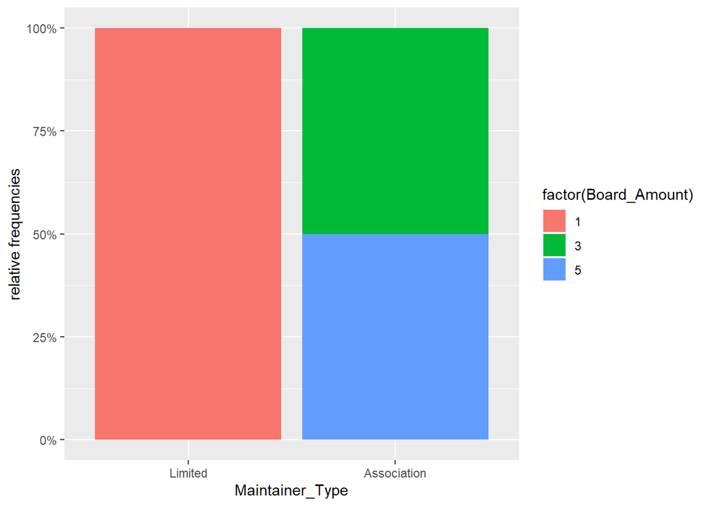

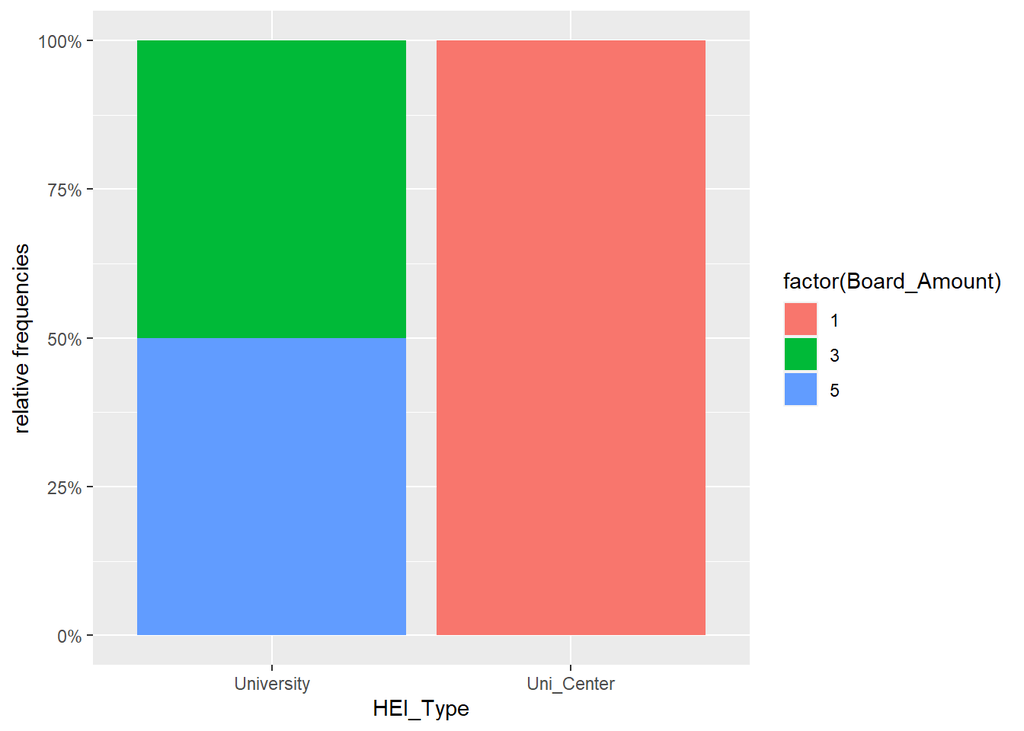

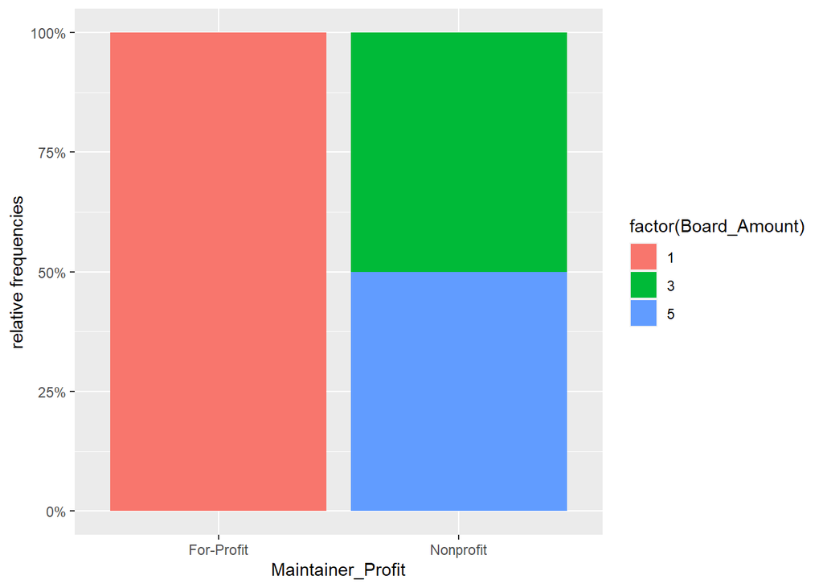

## Stakeholder representation

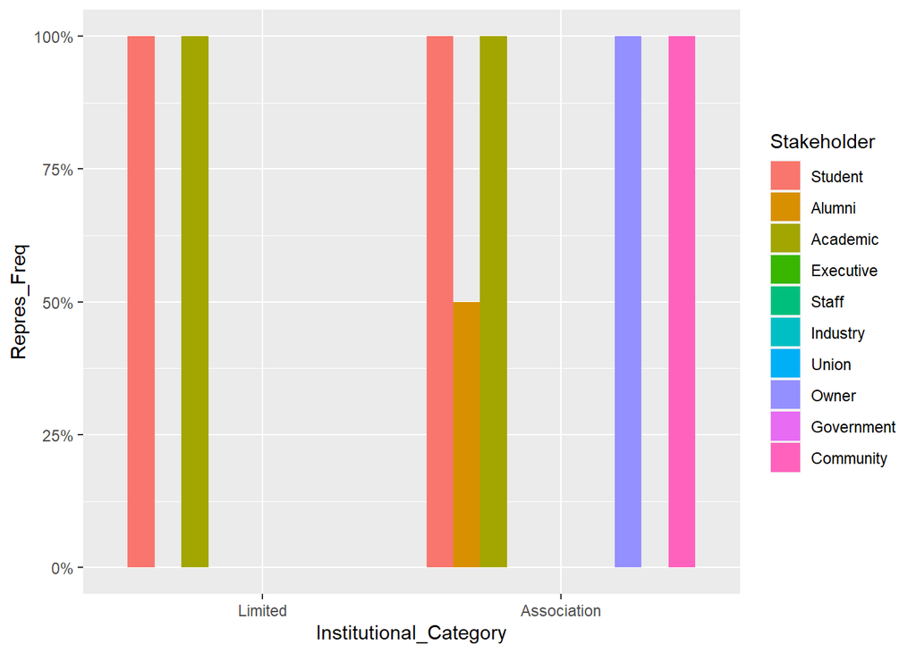

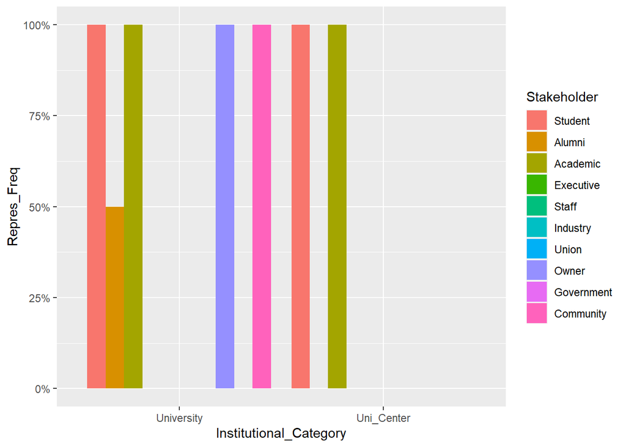

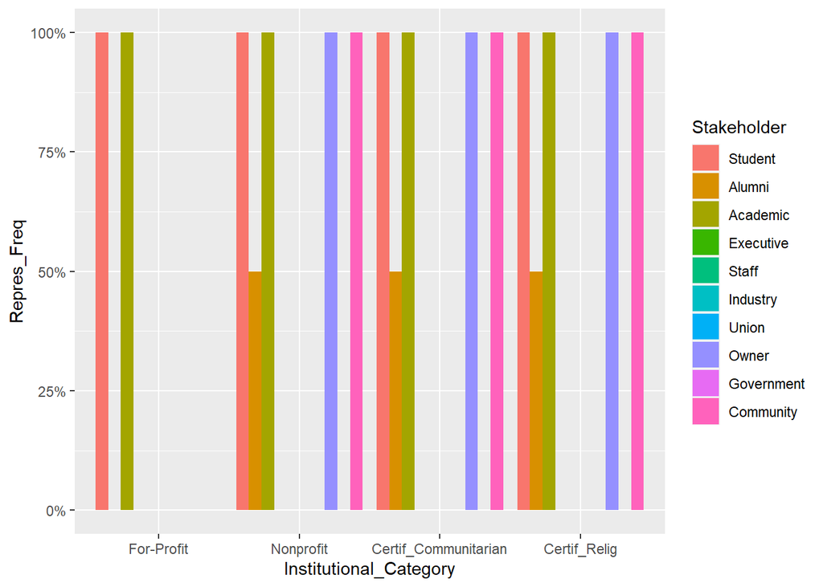

## Responsibility

### Academic

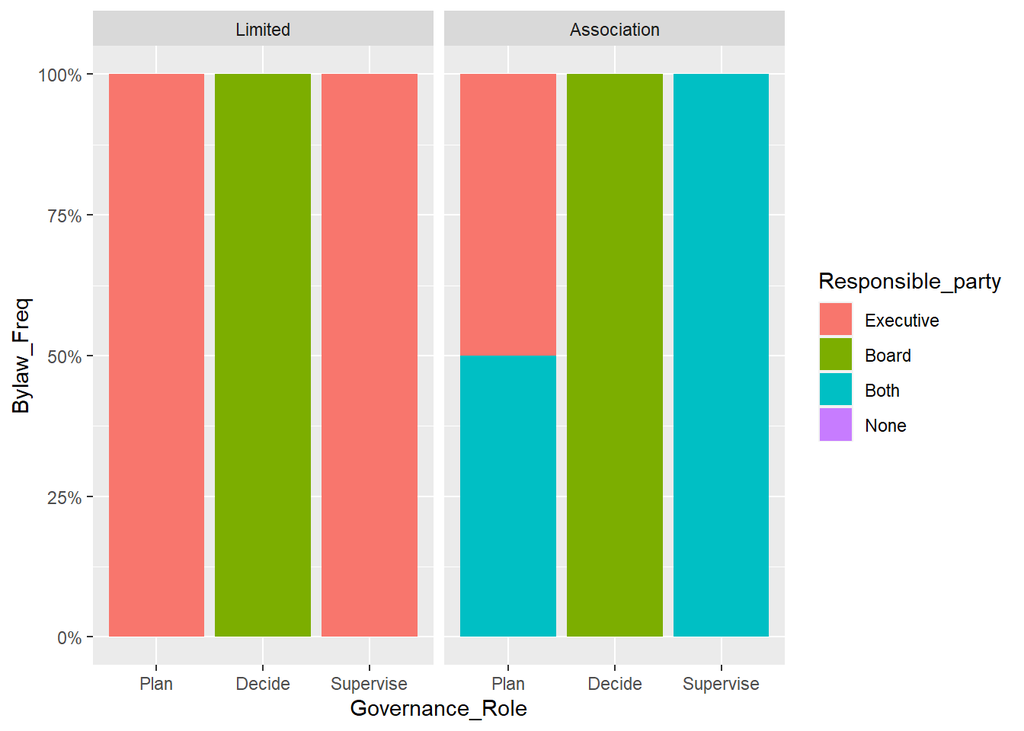

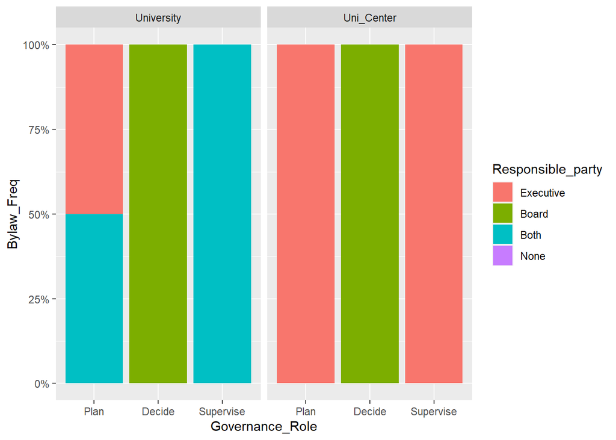

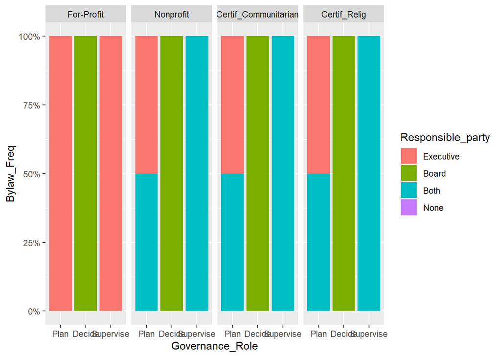

### Financial

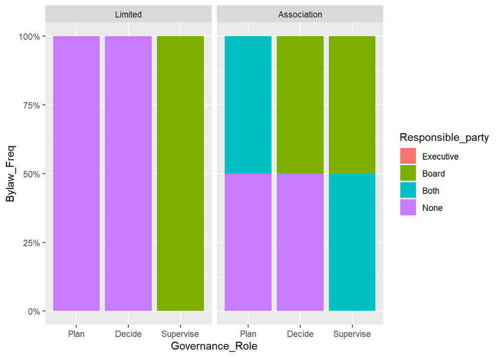

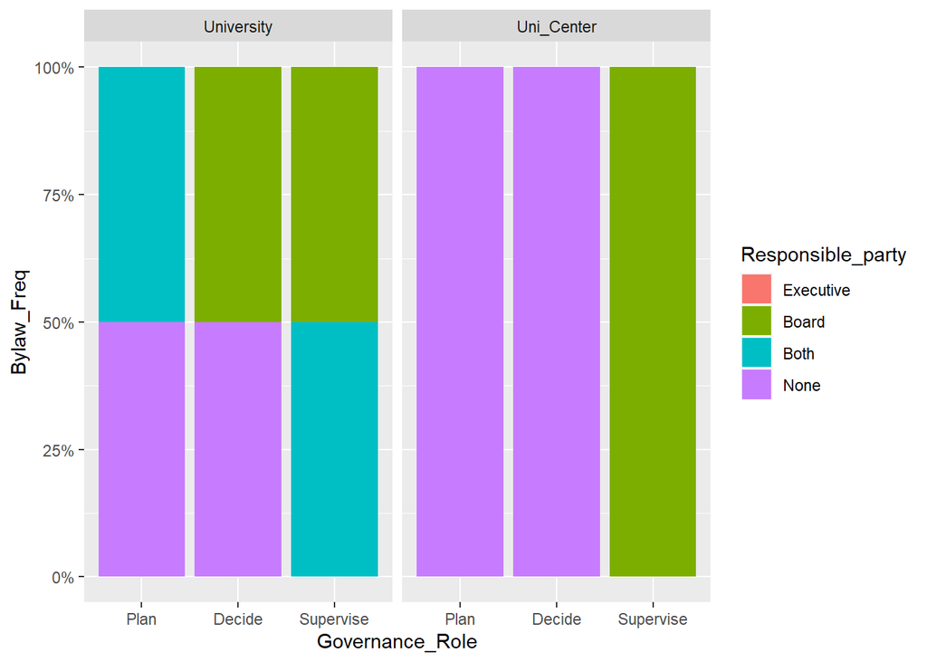

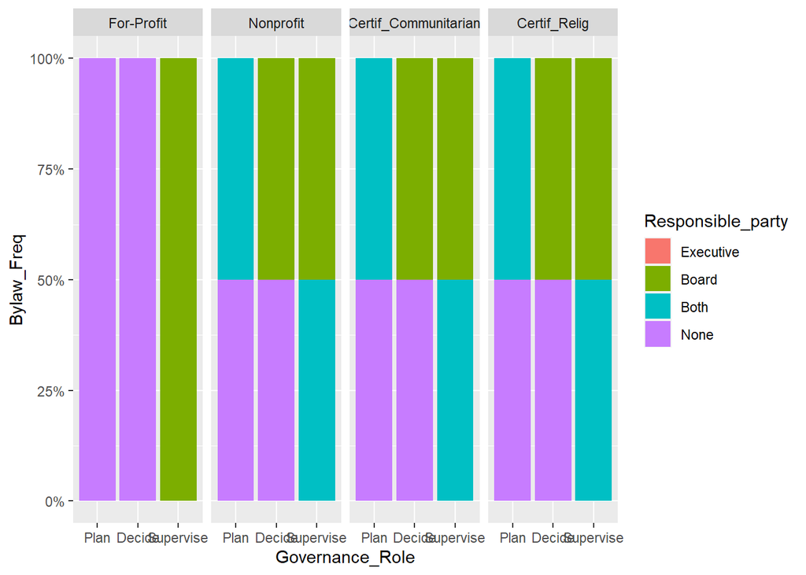

### Organizational

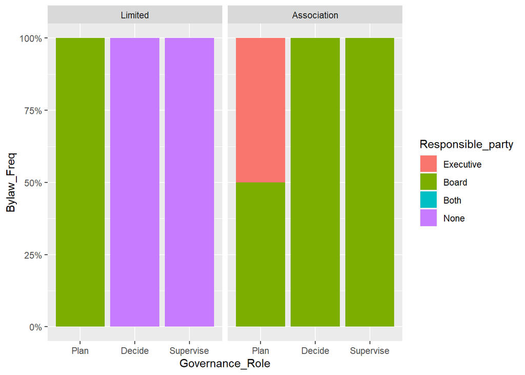

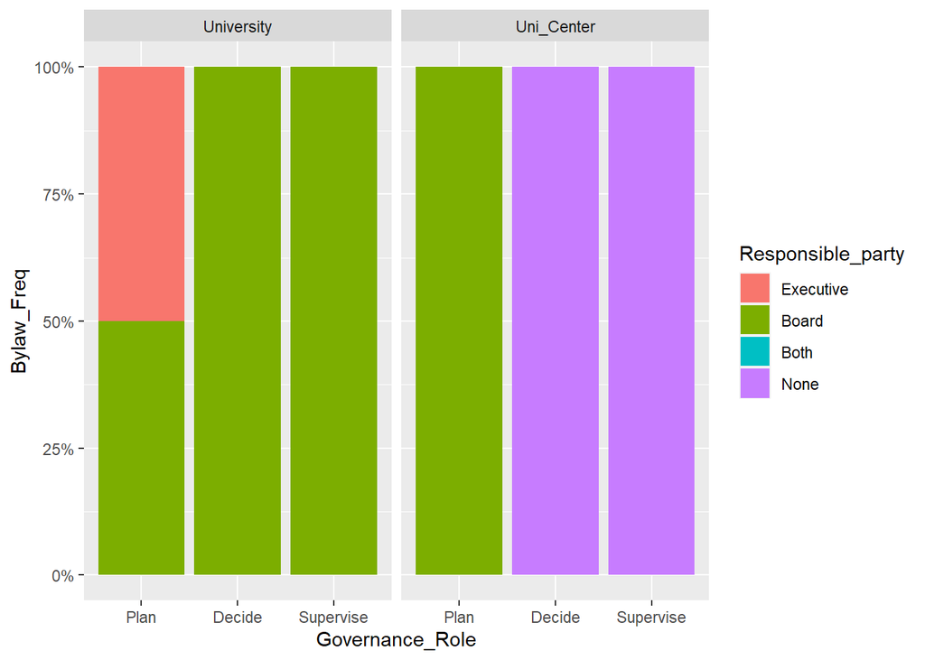

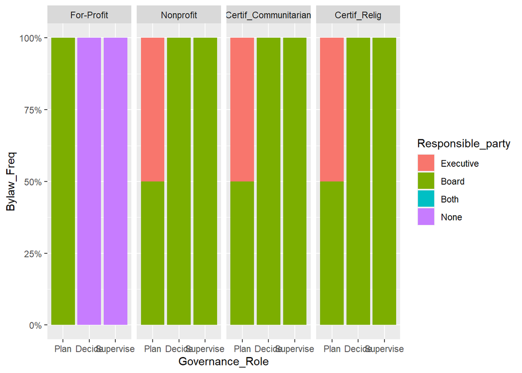

### Staffing

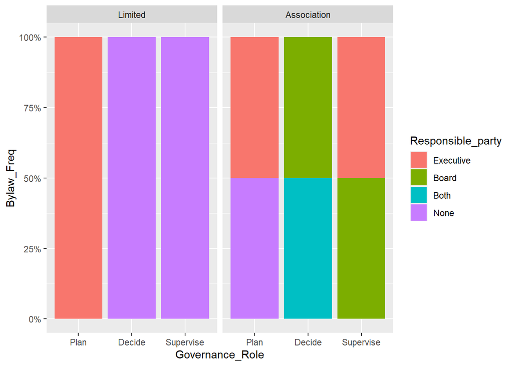

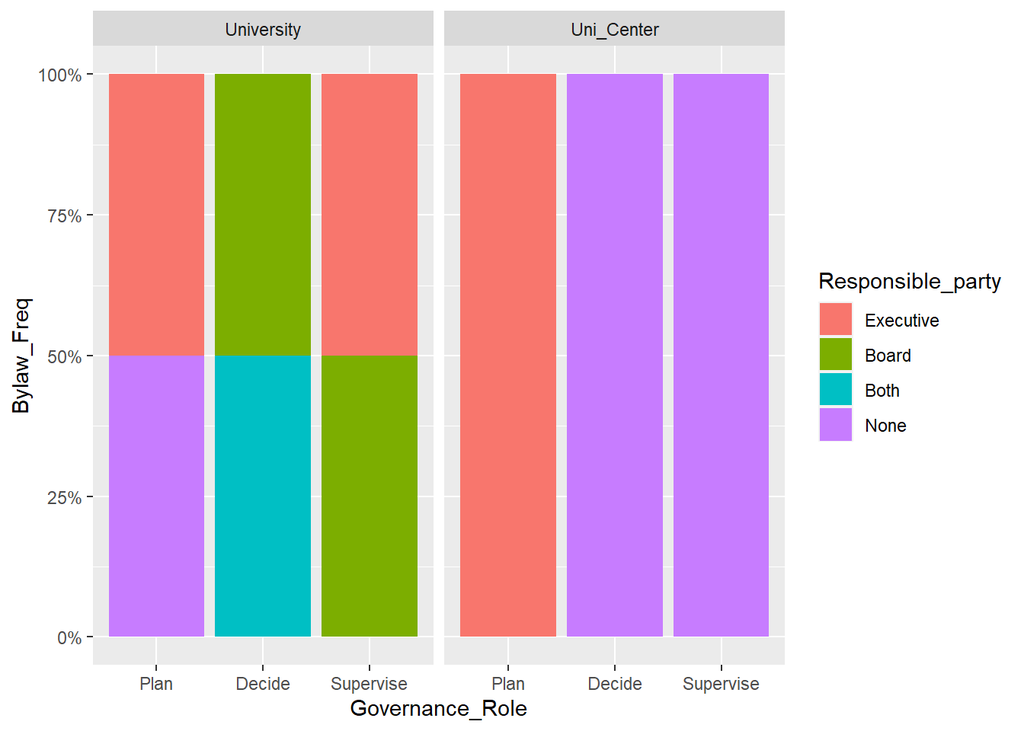

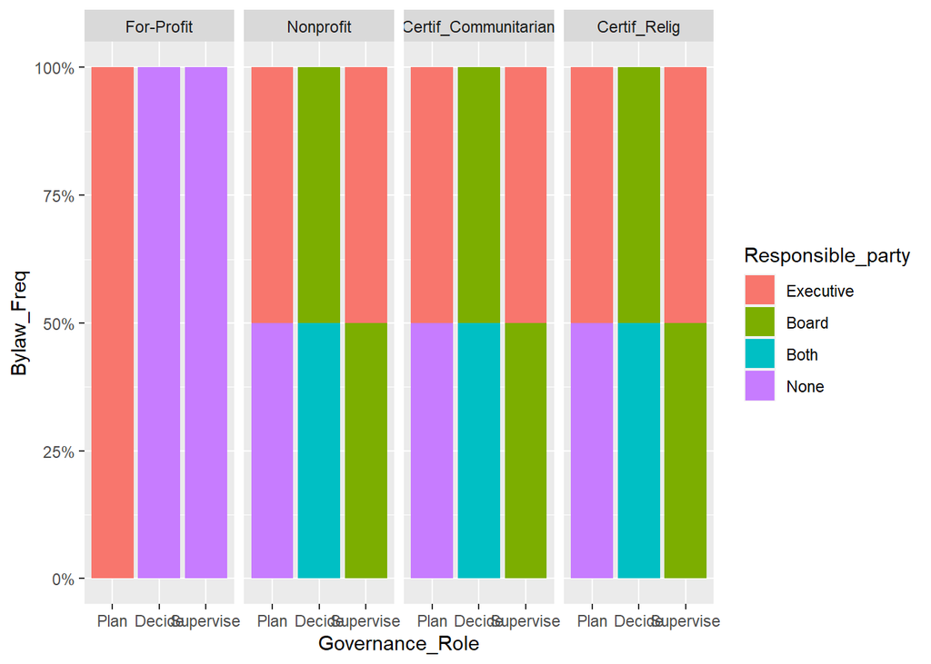

# Apendix

## Dictionary of variables

| **Code** | **Variable** | **Values** |
| --- | --- | --- |
| **Institutional variables** |  |  |
| Maintainer_Type | Legal form of the maintainer | Association, Foundation, Special, Corporate (Anonymous Society) or Limited (Limited Liability Society & Simple Society) |
| HEI_Type | Academic level of the HEI | University, Uni_Center (Universitary Center) or Faculty |
| Certif_Communitarian | Posesion of the Communitarian Certification | TRUE or FALSE |
| Certif_Relig | Identifies itself as confessional | TRUE or FALSE |
| **Governance structures** |  |  |
| Board_Amount | Number of boards in the statute | numeric value |
| Rector_Appointment | Process of appointing the main executive | Universitocracy; Academicracy; Designatory-Colaborative; Designatory-Directive |
| **Stakeholder representation on the boards** |  |  |
| Repres_Student | Representatives for current enrolled students | TRUE or FALSE |
| Repres_Alumni | Representatives for graduated students | TRUE or FALSE |
| Repres_academic | Representatives for Lecturers and Professors | TRUE or FALSE |
| Repres_Staff | Representatives for non-academic staff | TRUE or FALSE |
| Repres_Owner | Representatives for the maintainer | TRUE or FALSE |
| Repres_Government | Representatives for Government at any level | TRUE or FALSE |
| Repres_Community | Representatives for community | TRUE or FALSE |
| Repres_Industry | businessperson or a representative | TRUE or FALSE |
| Repres_Union | Representatives for labor unions | TRUE or FALSE |
| **Distribution of responsibilities** |  |  |
| Plan_Academic | Academic Planning | Executive, Board, Both (Shared responsibilities) or None |
| Plan_Financial | Financial Planning | Executive, Board, Both (Shared responsibilities) or None |
| Plan_Org | Organizational Planning | Executive, Board, Both (Shared responsibilities) or None |
| Plan_Staff | Staff Planning | Executive, Board, Both (Shared responsibilities) or None |
| Decide_Academic | Academic Decision-making | Executive, Board, Both (Shared responsibilities) or None |
| Decide_Financial | Financial Decision-making | Executive, Board, Both (Shared responsibilities) or None |
| Decide_Org | Organizational Decision-making | Executive, Board, Both (Shared responsibilities) or None |
| Decide_Staff | Staff Decision-making | Executive, Board, Both (Shared responsibilities) or None |
| Execute_Academic | Academic Execution | Executive, Board, Both (Shared responsibilities) or None |
| Execute_Financial | Financial Execution | Executive, Board, Both (Shared responsibilities) or None |
| Execute_Org | Organizational Execution | Executive, Board, Both (Shared responsibilities) or None |
| Execute_Staff | Staff Execution | Executive, Board, Both (Shared responsibilities) or None |
| Supervise_Academic | Academic Supervision | Executive, Board, Both (Shared responsibilities) or None |
| Supervise_Financial | Financial Supervision | Executive, Board, Both (Shared responsibilities) or None |
| Supervise_Org | Organizational Supervision | Executive, Board, Both (Shared responsibilities) or None |
| Supervise_Staff | Staff Supervision | Executive, Board, Both (Shared responsibilities) or None |
| Maintainer_Profit | Legal possibility of paying dividends | For-Profit or Nonprofit |